# A primer on statistical outbreak analysis

2017-11-26

## Analysing incidence data

## What is incidence?

**Definition:** the incidence is the number of new cases on a given time period.

- rely on dates, typically of onset of symptoms
- only daily incidence is non ambiguous
- other definitions (e.g. weekly) rely on a starting date
- prone to reporting delays

## Log-linear model of incidence

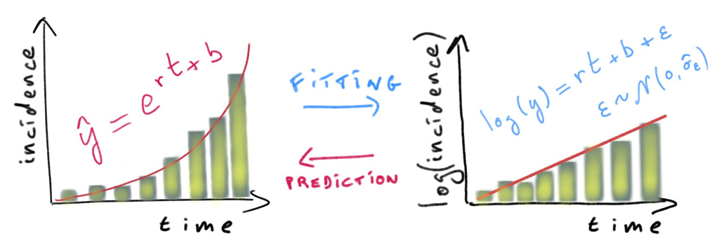

\(log(y) = r \times t + b + \epsilon\:\:\) so that \(\:\:\hat{y} = e^{r \times t + b}\)

with:

- \(r\): growth rate
- b: intercept
- \(\epsilon \sim \mathcal{N}(0, \hat{\sigma_{\epsilon}})\)

## Doubling time

Let \(T\) be the time taken by the incidence to double, given a daily growth rate \(r\).

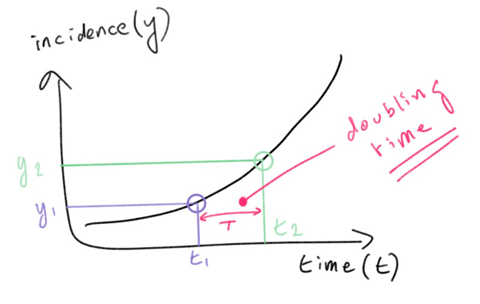

\[ y_2 / y_1 = 2 \:\: \Leftrightarrow e^{rt_2 + b} / e^{rt_1 + b} = 2 \]

\[ \Leftrightarrow e^{r(t_2 - t_1)} = 2 \Leftrightarrow T = log(2) / r \]

## Log-linear model: pros and cons

**Pros**:

- fast and simple
- predictions possible
- doubling / halving time readily available
- possible extensions to estimate \(R_0\) from \(r\)

**Cons**:

- zero incidence problematic
- non mechanistic
- no inclusion of other information (e.g. serial interval)

## The serial interval

**Definition:** time interval between onset of symptoms of a case and onset in the secondary cases they created.

Characterised for a number of existing diseases.

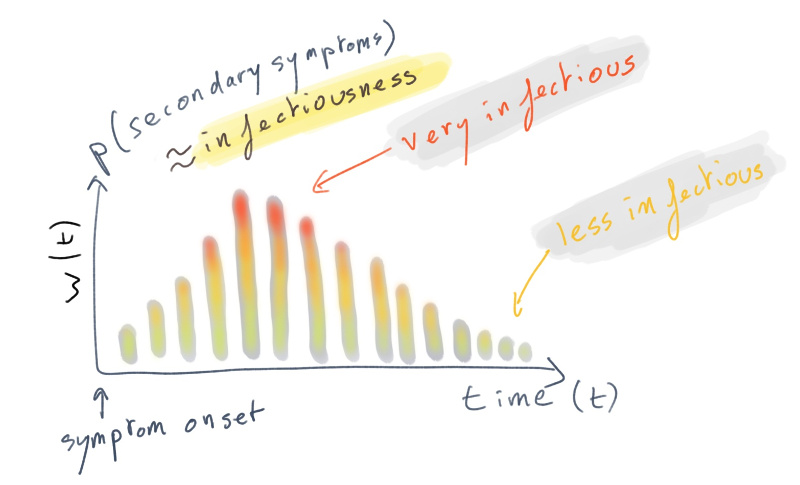

## Modelling infectiousness over time

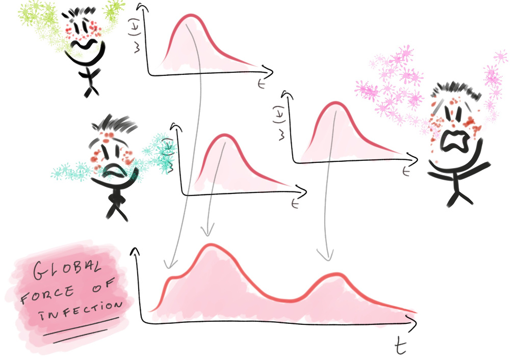

\[ \lambda_t = R_0 \times \sum_i w(t - t_i) \]

with: \(\lambda_t\): global force of infection; \(w()\): serial interval distribution; \(t_i\): date of symptom onset

## A Poisson model of incidence

[figure not shown]

Treat incidence \(y_t\) on day \(t\) as a Poisson distribution of rate \(\lambda_t\):

\[ p(y_t | R_0, y_1, ..., y_{t-1}) = e^{-\lambda_t} \frac{\lambda_t^{y_t}}{(!y_t)} \] with (slight rewriting): \(\lambda_t = R_0 \times \sum_{s = 1}^{t-1} y_s w(t - s)\)

## Poisson model: pros and cons

**Pros**:

- still fast, reasonably simple (1 parameter)
- accommodates zero incidence
- predictions possible: forward simulation (Poisson)
- integrates information on serial interval
- extension to time-varying \(R\) (*EpiEstim*)

**Cons**:

- needs information on serial interval
- no spatial processes
- assumes constant reporting
- likelihood / Bayesian methods harder to communicate

## Inferring who infected whom

## General idea

Original *outbreaker* model used serial interval and genetic data to reconstruct transmission events.

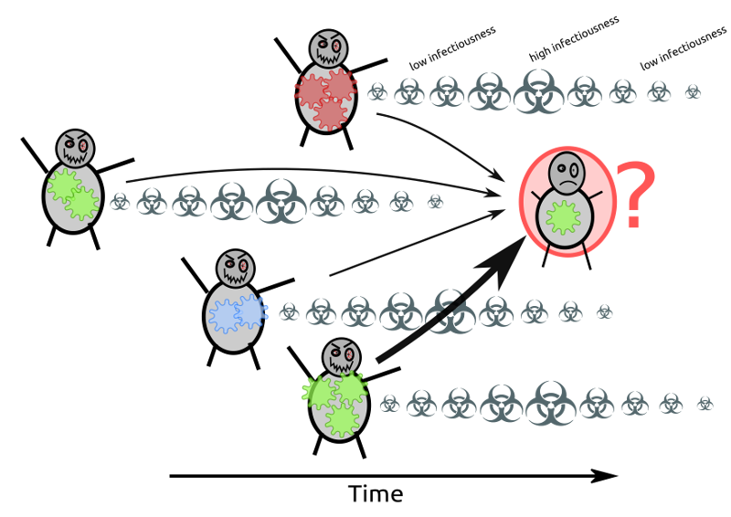

## *outbreaker2*: a modular platform for outbreak reconstruction

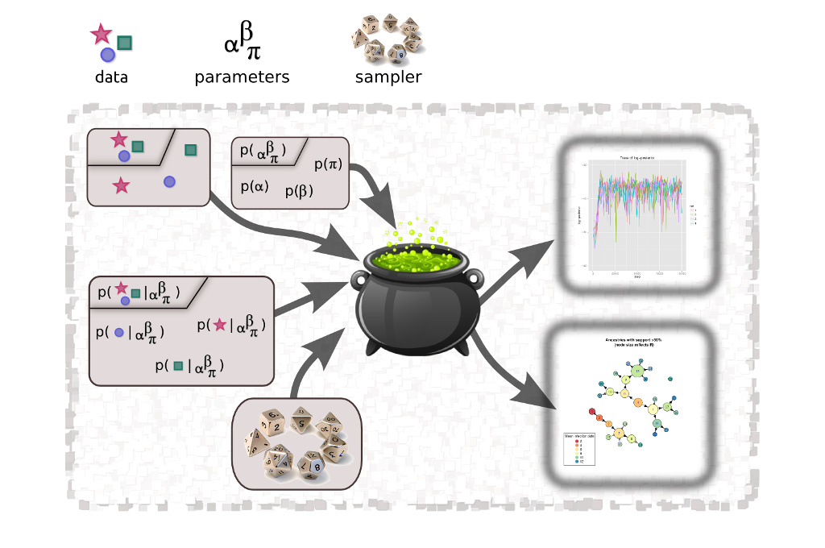

## Temporal likelihood

**Relies on:** dates on symptom onset (\(t_i\)), generation time (\(w()\)), incubation period (\(f()\)), number of generations (\(\kappa_i\)).

[figure not shown]

\[ p(t_i | T_i^{inf}) \times p(T_i^{inf} | T_{\alpha_i}^{inf}, \kappa_i) \]

\[ = f(t_i - T_i^{inf}) \times w^{(\kappa_i)}(T_i^{inf} - T_{\alpha_i}^{inf}) \]

## Reporting likelihood

**Relies on:**

- \(\kappa_i\): number of generations between case \(i\) and its more recent sampled "ancestor"
- \(\pi\) case reporting probability

**Geometric distribution:**

\[ p(\kappa_i | \pi) = (1 - \pi^{})^{\kappa_i - 1} \times \pi \]

## Genetic likelihood

**Relies on:**

- \(d()\): number of mutations between 2 sequences
- \(s_i\), \(s_{\alpha_i}\): sequences of infectee their infector
- \(L\): genome length
- \(\mu\): mutation rate per generation of infection

\[ p(s_i | s_{\alpha_i} \mu) = \mu^{d(s_i, s_{\alpha_i})} \times (1 - \mu)^{(\kappa_i L - d(s_i, s_{\alpha_i}))} \]

## Contact likelihood

**Relies on:** contact reporting probability (\(\epsilon\)) and probability of contact between non-transmission pairs (\(\lambda\)).

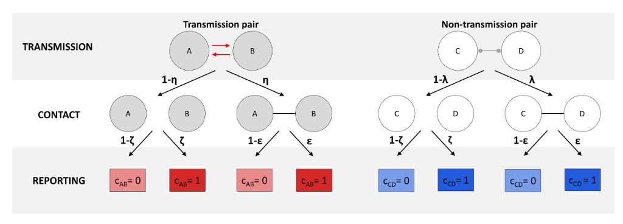

\(\alpha_i = j\): \(p(c_{i,j} = 1 ) = \epsilon\) ; \(p(c_{i,j} = 0) = 1 - \epsilon\)

\(\alpha_i \neq j\): \(p(c_{i,j} = 1) = \lambda \epsilon\) ; \(p(c_{i,j} = 0) = (1 - \lambda) + \lambda (1 - \epsilon)\)